# Baseball Statistics Regression

Lance Dugger

## Problem Description

The moneyball data set is a csv file consisting of 17 columns describing different statistics for baseball teams during the regular season. Each row represents a regular season for a certain team. The data set includes a wins column to indicate how many wins each team had during the season. Different regression methods will be used to develop a model to predict total wins during a season based on a baseball team’s statistics.

## Data Exploration

```r
str(moneyball)
```

```
## 'data.frame':    2276 obs. of  17 variables:
##  $ INDEX           : int  1 2 3 4 5 6 7 8 11 12 ...
##  $ TARGET_WINS     : int  39 70 86 70 82 75 80 85 86 76 ...
##  $ TEAM_BATTING_H  : int  1445 1339 1377 1387 1297 1279 1244 1273 1391 1271 ...
##  $ TEAM_BATTING_2B : int  194 219 232 209 186 200 179 171 197 213 ...
##  $ TEAM_BATTING_3B : int  39 22 35 38 27 36 54 37 40 18 ...
##  $ TEAM_BATTING_HR : int  13 190 137 96 102 92 122 115 114 96 ...
##  $ TEAM_BATTING_BB : int  143 685 602 451 472 443 525 456 447 441 ...
##  $ TEAM_BATTING_SO : int  842 1075 917 922 920 973 1062 1027 922 827 ...
##  $ TEAM_BASERUN_SB : int  NA 37 46 43 49 107 80 40 69 72 ...
##  $ TEAM_BASERUN_CS : int  NA 28 27 30 39 59 54 36 27 34 ...
##  $ TEAM_BATTING_HBP: int  NA NA NA NA NA NA NA NA NA NA ...
##  $ TEAM_PITCHING_H : int  9364 1347 1377 1396 1297 1279 1244 1281 1391 1271 ...
##  $ TEAM_PITCHING_HR: int  84 191 137 97 102 92 122 116 114 96 ...
##  $ TEAM_PITCHING_BB: int  927 689 602 454 472 443 525 459 447 441 ...
##  $ TEAM_PITCHING_SO: int  5456 1082 917 928 920 973 1062 1033 922 827 ...
##  $ TEAM_FIELDING_E : int  1011 193 175 164 138 123 136 112 127 131 ...
##  $ TEAM_FIELDING_DP: int  NA 155 153 156 168 149 186 136 169 159 ...
```

```r
summary(moneyball)
```

|  | INDEX | TARGET_WINS | TEAM_BATTING_H | TEAM_BATTING_2B | TEAM_BATTING_3B | TEAM_BATTING_HR | TEAM_BATTING_BB | TEAM_BATTING_SO | TEAM_BASERUN_SB | TEAM_BASERUN_CS | TEAM_BATTING_HBP | TEAM_PITCHING_H | TEAM_PITCHING_HR | TEAM_PITCHING_BB | TEAM_PITCHING_SO | TEAM_FIELDING_E | TEAM_FIELDING_DP |
| --- | --- | --- | --- | --- | --- | --- | --- | --- | --- | --- | --- | --- | --- | --- | --- | --- | --- |
|  | Min. : 1.0 | Min. : 0.00 | Min. : 891 | Min. : 69.0 | Min. : 0.00 | Min. : 0.00 | Min. : 0.0 | Min. : 0.0 | Min. : 0.0 | Min. : 0.0 | Min. :29.00 | Min. : 1137 | Min. : 0.0 | Min. : 0.0 | Min. : 0.0 | Min. : 65.0 | Min. : 52.0 |
|  | 1st Qu.: 630.8 | 1st Qu.: 71.00 | 1st Qu.:1383 | 1st Qu.:208.0 | 1st Qu.: 34.00 | 1st Qu.: 42.00 | 1st Qu.:451.0 | 1st Qu.: 548.0 | 1st Qu.: 66.0 | 1st Qu.: 38.0 | 1st Qu.:50.50 | 1st Qu.: 1419 | 1st Qu.: 50.0 | 1st Qu.: 476.0 | 1st Qu.: 615.0 | 1st Qu.: 127.0 | 1st Qu.:131.0 |
|  | Median :1270.5 | Median : 82.00 | Median :1454 | Median :238.0 | Median : 47.00 | Median :102.00 | Median :512.0 | Median : 750.0 | Median :101.0 | Median : 49.0 | Median :58.00 | Median : 1518 | Median :107.0 | Median : 536.5 | Median : 813.5 | Median : 159.0 | Median :149.0 |
|  | Mean :1268.5 | Mean : 80.79 | Mean :1469 | Mean :241.2 | Mean : 55.25 | Mean : 99.61 | Mean :501.6 | Mean : 735.6 | Mean :124.8 | Mean : 52.8 | Mean :59.36 | Mean : 1779 | Mean :105.7 | Mean : 553.0 | Mean : 817.7 | Mean : 246.5 | Mean :146.4 |
|  | 3rd Qu.:1915.5 | 3rd Qu.: 92.00 | 3rd Qu.:1537 | 3rd Qu.:273.0 | 3rd Qu.: 72.00 | 3rd Qu.:147.00 | 3rd Qu.:580.0 | 3rd Qu.: 930.0 | 3rd Qu.:156.0 | 3rd Qu.: 62.0 | 3rd Qu.:67.00 | 3rd Qu.: 1682 | 3rd Qu.:150.0 | 3rd Qu.: 611.0 | 3rd Qu.: 968.0 | 3rd Qu.: 249.2 | 3rd Qu.:164.0 |
|  | Max. :2535.0 | Max. :146.00 | Max. :2554 | Max. :458.0 | Max. :223.00 | Max. :264.00 | Max. :878.0 | Max. :1399.0 | Max. :697.0 | Max. :201.0 | Max. :95.00 | Max. :30132 | Max. :343.0 | Max. :3645.0 | Max. :19278.0 | Max. :1898.0 | Max. :228.0 |
|  | NA | NA | NA | NA | NA | NA | NA | NA’s :102 | NA’s :131 | NA’s :772 | NA’s :2085 | NA | NA | NA | NA’s :102 | NA | NA’s :286 |

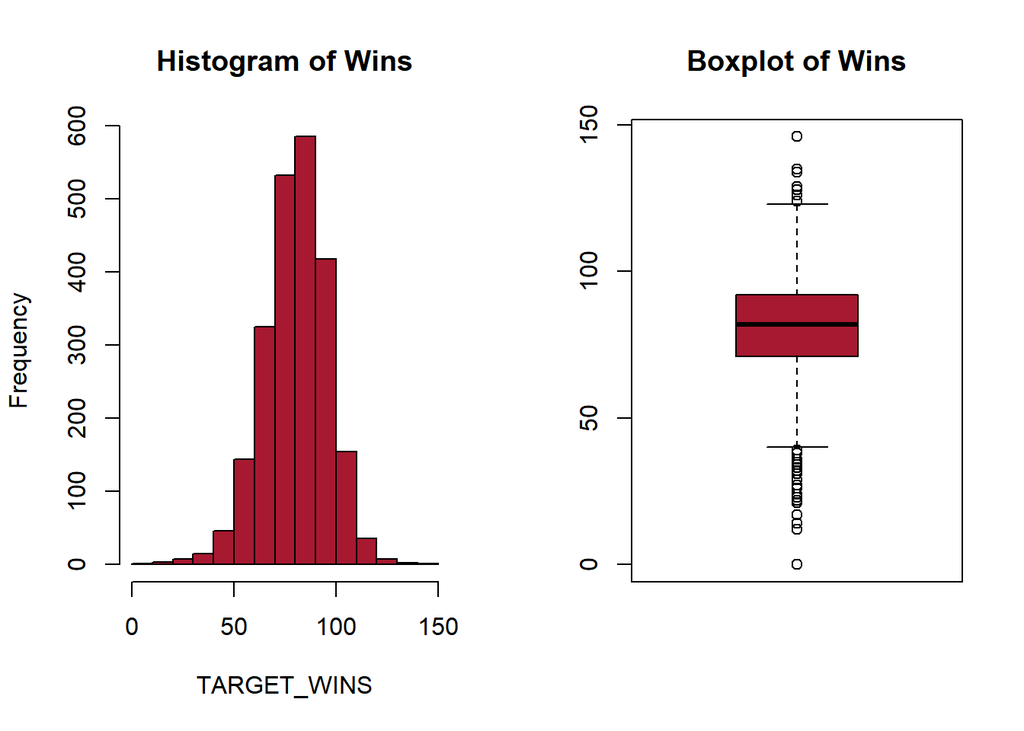

```r
# Wins - Use lower bound for lower outliers, upper bound for higher outliers.
par(mfrow=c(1,2))
hist(moneyball$TARGET_WINS, col = "#A71930", xlab = "TARGET_WINS", main = "Histogram of Wins")
boxplot(moneyball$TARGET_WINS, col = "#A71930", main = "Boxplot of Wins")
```

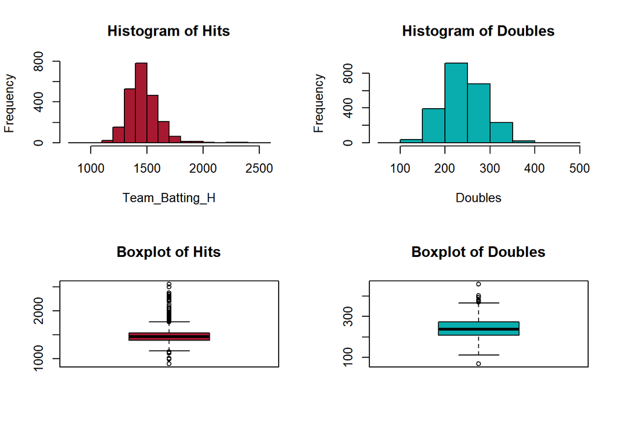

```r
# Hits and Doubles
par(mfrow=c(2,2))
hist(moneyball$TEAM_BATTING_H, col = "#A71930", xlab = "Team_Batting_H", main = "Histogram of Hits")
hist(moneyball$TEAM_BATTING_2B, col = "#09ADAD", xlab = "Doubles", main = "Histogram of Doubles")
boxplot(moneyball$TEAM_BATTING_H, col = "#A71930", main = "Boxplot of Hits")
boxplot(moneyball$TEAM_BATTING_2B, col = "#09ADAD", main = "Boxplot of Doubles")
```

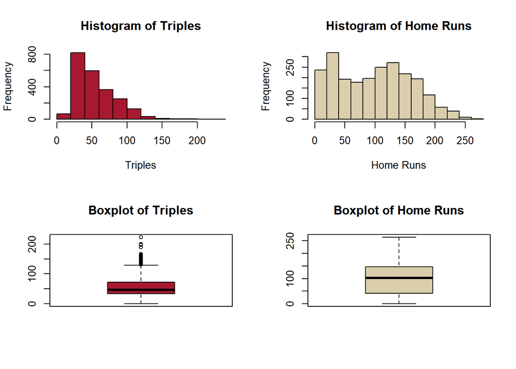

```r
# Triples and Home Runs
par(mfrow=c(2,2))
hist(moneyball$TEAM_BATTING_3B, col = "#A71930", xlab = "Triples", main = "Histogram of Triples")
hist(moneyball$TEAM_BATTING_HR, col = "#DBCEAC", xlab = "Home Runs", main = "Histogram of Home Runs")
boxplot(moneyball$TEAM_BATTING_3B, col = "#A71930", main = "Boxplot of Triples")
boxplot(moneyball$TEAM_BATTING_HR, col = "#DBCEAC", main = "Boxplot of Home Runs")
```

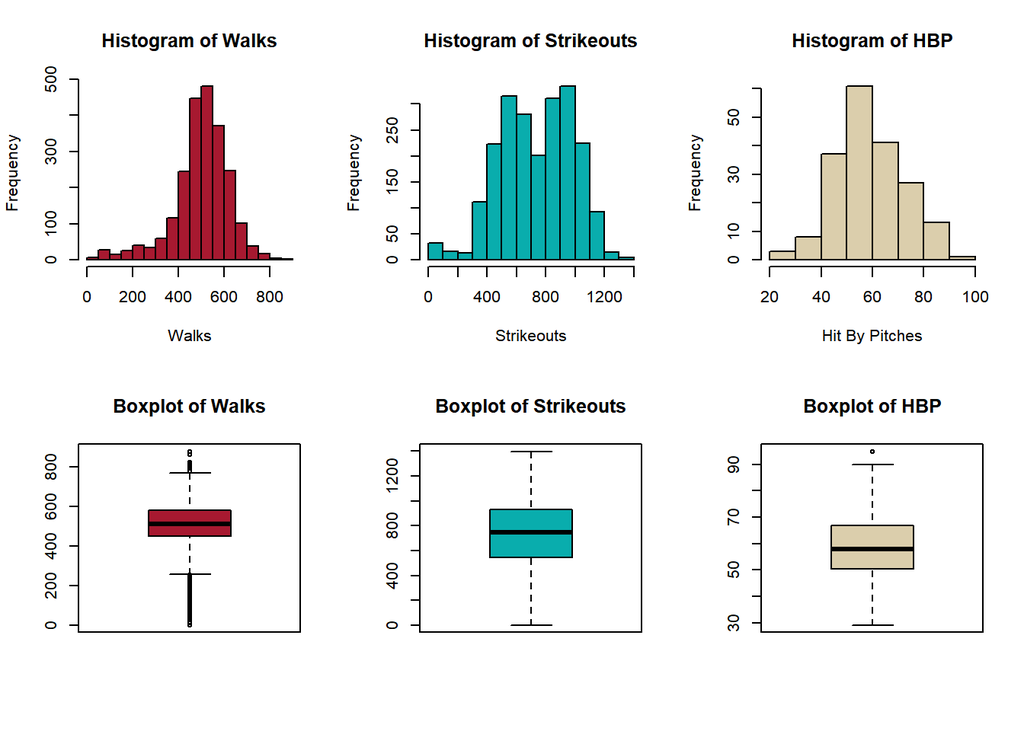

```r
# Walks, Strikeouts, HBP
par(mfrow=c(2,3))
hist(moneyball$TEAM_BATTING_BB, col = "#A71930", xlab = "Walks", main = "Histogram of Walks")
hist(moneyball$TEAM_BATTING_SO, col = "#09ADAD", xlab = "Strikeouts", main = "Histogram of Strikeouts")
hist(moneyball$TEAM_BATTING_HBP, col = "#DBCEAC", xlab = "Hit By Pitches", main = "Histogram of HBP")
boxplot(moneyball$TEAM_BATTING_BB, col = "#A71930", main = "Boxplot of Walks")
boxplot(moneyball$TEAM_BATTING_SO, col = "#09ADAD", main = "Boxplot of Strikeouts")
boxplot(moneyball$TEAM_BATTING_HBP, col = "#DBCEAC", main = "Boxplot of HBP")
```

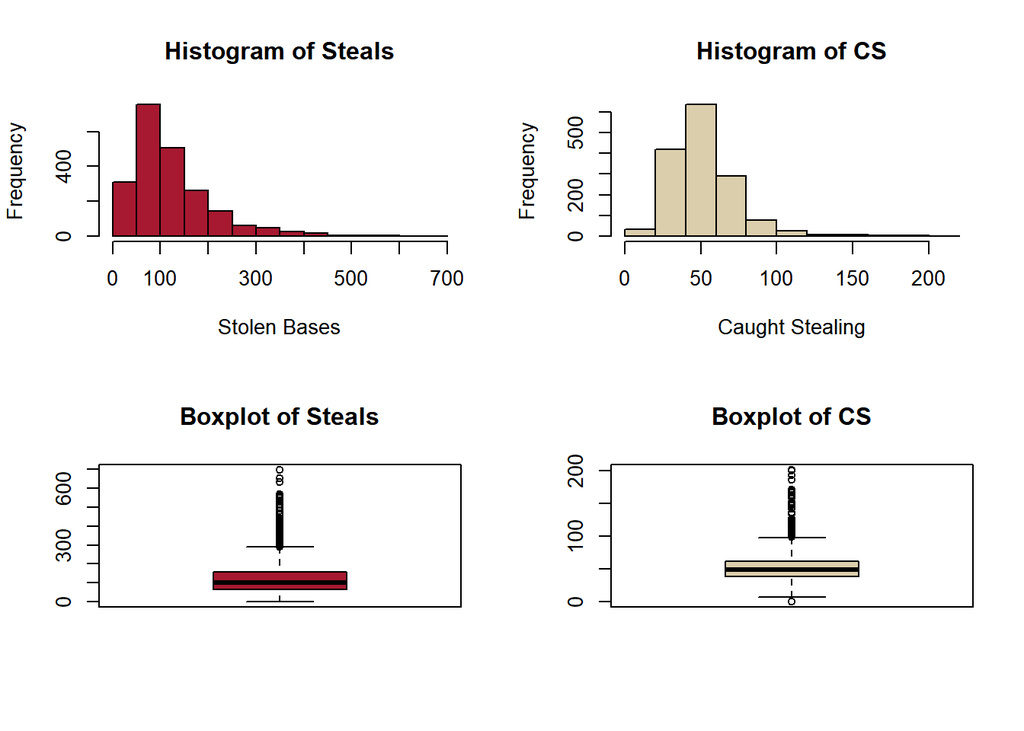

```r
# Stolen Bases and Caught Stealing
par(mfrow=c(2,2))
hist(moneyball$TEAM_BASERUN_SB, col = "#A71930", xlab = "Stolen Bases", main = "Histogram of Steals")
hist(moneyball$TEAM_BASERUN_CS, col = "#DBCEAC", xlab = "Caught Stealing", main = "Histogram of CS")
boxplot(moneyball$TEAM_BASERUN_SB, col = "#A71930", main = "Boxplot of Steals")
boxplot(moneyball$TEAM_BASERUN_CS, col = "#DBCEAC", main = "Boxplot of CS")
```

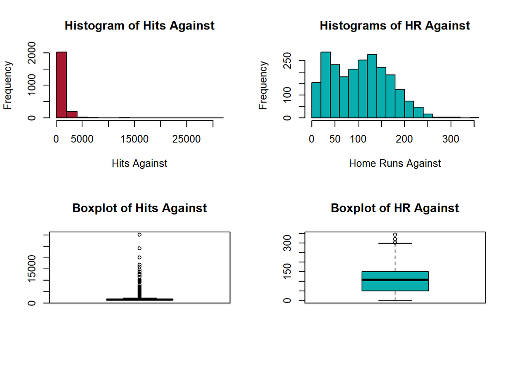

```r
# Hits and Home Runs
par(mfrow=c(2,2))
hist(moneyball$TEAM_PITCHING_H, col = "#A71930", xlab = "Hits Against", main = "Histogram of Hits Against")
hist(moneyball$TEAM_PITCHING_HR, col = "#09ADAD", xlab = "Home Runs Against", main = "Histograms of HR Against")
boxplot(moneyball$TEAM_PITCHING_H, col = "#A71930", main = "Boxplot of Hits Against")
boxplot(moneyball$TEAM_PITCHING_HR, col = "#09ADAD", main = "Boxplot of HR Against")
```

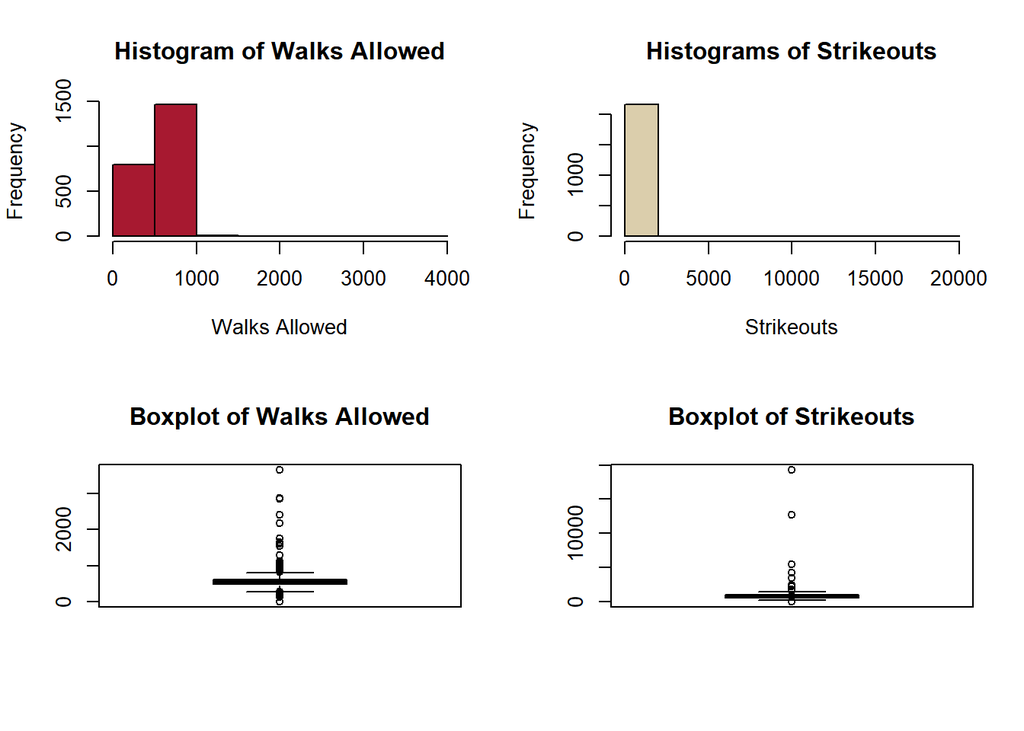

```r
# Walks and Strikeouts
par(mfrow=c(2,2))
hist(moneyball$TEAM_PITCHING_BB, col = "#A71930", xlab = "Walks Allowed", main = "Histogram of Walks Allowed")
hist(moneyball$TEAM_PITCHING_SO, col = "#DBCEAC", xlab = "Strikeouts", main = "Histograms of Strikeouts")
boxplot(moneyball$TEAM_PITCHING_BB, col = "#A71930", main = "Boxplot of Walks Allowed")
boxplot(moneyball$TEAM_PITCHING_SO, col = "#DBCEAC", main = "Boxplot of Strikeouts")
```

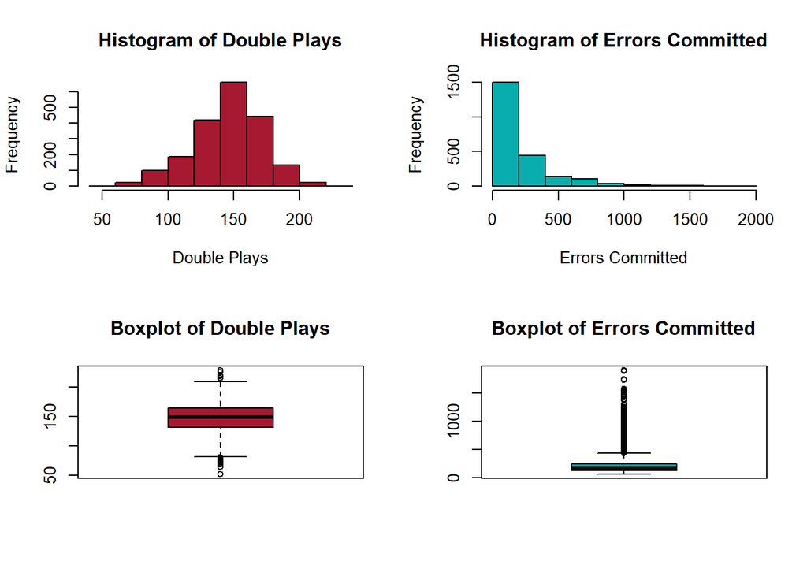

```r
# Double Plays and Errors
par(mfrow=c(2,2))
hist(moneyball$TEAM_FIELDING_DP, col = "#A71930", xlab = "Double Plays", main = "Histogram of Double Plays")
hist(moneyball$TEAM_FIELDING_E, col = "#09ADAD", xlab = "Errors Committed", main = "Histogram of Errors Committed")
boxplot(moneyball$TEAM_FIELDING_DP, col = "#A71930", main = "Boxplot of Double Plays")
boxplot(moneyball$TEAM_FIELDING_E, col = "#09ADAD", main = "Boxplot of Errors Committed")
```

## Data Preparation

```r
#Remove Index column
moneyball <- subset(moneyball, select = -INDEX)

#Add Base Hit Column
moneyball$TEAM_BATTING_1B <- moneyball$TEAM_BATTING_H - moneyball$TEAM_BATTING_HR - moneyball$TEAM_BATTING_3B -
  moneyball$TEAM_BATTING_2B

#Add no hit column
moneyball$TEAM_BATTING_NH <- moneyball$TEAM_BATTING_BB - moneyball$TEAM_BATTING_SO

#Add stolen base percentage column
moneyball$TEAM_BASERUN_SBP <- moneyball$TEAM_BASERUN_SB/(moneyball$TEAM_BASERUN_SB+moneyball$TEAM_BASERUN_CS)

#Set column number variable so it does not increase as flag columns are added
cols <- ncol(moneyball)

#Iterate through dataframe to correct outliers and NA's
for (i in 1:cols){
  #Add flag column for na's and replace value with median
  moneyball$flagna <- ifelse(is.na(moneyball[[i]]), 1, 0)
  moneyball[[i]][is.na(moneyball[[i]])] = median(moneyball[[i]], na.rm = TRUE)

  #Add flag column for outliers and change value to 2nd or 98th percentile
  moneyball$flagout <- if_else(moneyball[[i]] > quantile(moneyball[[i]], 0.98) | moneyball[[i]] < quantile(moneyball[[i]], 0.02), 1, 0)
  moneyball[[i]] <- ifelse(moneyball[[i]] > quantile(moneyball[[i]], 0.98), quantile(moneyball[[i]], 0.98), moneyball[[i]])
  moneyball[[i]] <- ifelse(moneyball[[i]] < quantile(moneyball[[i]], 0.02), quantile(moneyball[[i]], 0.02), moneyball[[i]])

  #Rename flag columns
  moneyball <- rename_with(moneyball, .fn = ~paste0("FLAGNA_", colnames(moneyball[i]), sep = ""), .cols = flagna)
  moneyball <- rename_with(moneyball, .fn = ~paste0("FLAGOUT_", colnames(moneyball[i]), sep = ""), .cols = flagout)
}

#Check that na's are gone.
summary(moneyball)
```

|  | TARGET_WINS | TEAM_BATTING_H | TEAM_BATTING_2B | TEAM_BATTING_3B | TEAM_BATTING_HR | TEAM_BATTING_BB | TEAM_BATTING_SO | TEAM_BASERUN_SB | TEAM_BASERUN_CS | TEAM_BATTING_HBP | TEAM_PITCHING_H | TEAM_PITCHING_HR | TEAM_PITCHING_BB | TEAM_PITCHING_SO | TEAM_FIELDING_E | TEAM_FIELDING_DP | TEAM_BATTING_1B | TEAM_BATTING_NH | TEAM_BASERUN_SBP | FLAGNA_TARGET_WINS | FLAGOUT_TARGET_WINS | FLAGNA_TEAM_BATTING_H | FLAGOUT_TEAM_BATTING_H | FLAGNA_TEAM_BATTING_2B | FLAGOUT_TEAM_BATTING_2B | FLAGNA_TEAM_BATTING_3B | FLAGOUT_TEAM_BATTING_3B | FLAGNA_TEAM_BATTING_HR | FLAGOUT_TEAM_BATTING_HR | … |
| --- | --- | --- | --- | --- | --- | --- | --- | --- | --- | --- | --- | --- | --- | --- | --- | --- | --- | --- | --- | --- | --- | --- | --- | --- | --- | --- | --- | --- | --- | --- |
|  | Min. : 45.00 | Min. :1229 | Min. :154.5 | Min. : 19.50 | Min. : 8.00 | Min. :146 | Min. : 167.5 | Min. : 28.0 | Min. : 22.00 | Min. :50.00 | Min. :1276 | Min. : 12.0 | Min. :320.0 | Min. : 366.5 | Min. : 90.0 | Min. : 86.0 | Min. : 897.5 | Min. :-645.0 | Min. :0.4579 | Min. :0 | Min. :0.00000 | Min. :0 | Min. :0.00000 | Min. :0 | Min. :0.00000 | Min. :0 | Min. :0.00000 | Min. :0 | Min. :0.00000 | … |
|  | 1st Qu.: 71.00 | 1st Qu.:1383 | 1st Qu.:208.0 | 1st Qu.: 34.00 | 1st Qu.: 42.00 | 1st Qu.:451 | 1st Qu.: 556.8 | 1st Qu.: 67.0 | 1st Qu.: 44.00 | 1st Qu.:58.00 | 1st Qu.:1419 | 1st Qu.: 50.0 | 1st Qu.:476.0 | 1st Qu.: 626.0 | 1st Qu.: 127.0 | 1st Qu.:134.0 | 1st Qu.: 990.8 | 1st Qu.:-396.0 | 1st Qu.:0.6123 | 1st Qu.:0 | 1st Qu.:0.00000 | 1st Qu.:0 | 1st Qu.:0.00000 | 1st Qu.:0 | 1st Qu.:0.00000 | 1st Qu.:0 | 1st Qu.:0.00000 | 1st Qu.:0 | 1st Qu.:0.00000 | … |
|  | Median : 82.00 | Median :1454 | Median :238.0 | Median : 47.00 | Median :102.00 | Median :512 | Median : 750.0 | Median :101.0 | Median : 49.00 | Median :58.00 | Median :1518 | Median :107.0 | Median :536.5 | Median : 813.5 | Median : 159.0 | Median :149.0 | Median :1050.0 | Median :-248.5 | Median :0.6429 | Median :0 | Median :0.00000 | Median :0 | Median :0.00000 | Median :0 | Median :0.00000 | Median :0 | Median :0.00000 | Median :0 | Median :0.00000 | … |
|  | Mean : 80.85 | Mean :1466 | Mean :241.1 | Mean : 54.93 | Mean : 99.43 | Mean :502 | Mean : 737.3 | Mean :121.8 | Mean : 50.94 | Mean :58.06 | Mean :1684 | Mean :105.3 | Mean :547.8 | Mean : 800.9 | Mean : 240.8 | Mean :146.7 | Mean :1069.8 | Mean :-231.1 | Mean :0.6366 | Mean :0 | Mean :0.03779 | Mean :0 | Mean :0.04042 | Mean :0 | Mean :0.04042 | Mean :0 | Mean :0.04042 | Mean :0 | Mean :0.03603 | … |
|  | 3rd Qu.: 92.00 | 3rd Qu.:1537 | 3rd Qu.:273.0 | 3rd Qu.: 72.00 | 3rd Qu.:147.00 | 3rd Qu.:580 | 3rd Qu.: 925.0 | 3rd Qu.:151.0 | 3rd Qu.: 54.25 | 3rd Qu.:58.00 | 3rd Qu.:1682 | 3rd Qu.:150.0 | 3rd Qu.:611.0 | 3rd Qu.: 957.0 | 3rd Qu.: 249.2 | 3rd Qu.:161.2 | 3rd Qu.:1129.0 | 3rd Qu.: -51.0 | 3rd Qu.:0.6685 | 3rd Qu.:0 | 3rd Qu.:0.00000 | 3rd Qu.:0 | 3rd Qu.:0.00000 | 3rd Qu.:0 | 3rd Qu.:0.00000 | 3rd Qu.:0 | 3rd Qu.:0.00000 | 3rd Qu.:0 | 3rd Qu.:0.00000 | … |
|  | Max. :110.50 | Max. :1799 | Max. :338.5 | Max. :122.50 | Max. :221.00 | Max. :713 | Max. :1159.5 | Max. :387.0 | Max. :102.50 | Max. :68.50 | Max. :4788 | Max. :231.0 | Max. :844.5 | Max. :1345.5 | Max. :1003.5 | Max. :193.0 | Max. :1415.0 | Max. : 212.5 | Max. :0.7683 | Max. :0 | Max. :1.00000 | Max. :0 | Max. :1.00000 | Max. :0 | Max. :1.00000 | Max. :0 | Max. :1.00000 | Max. :0 | Max. :1.00000 | … |

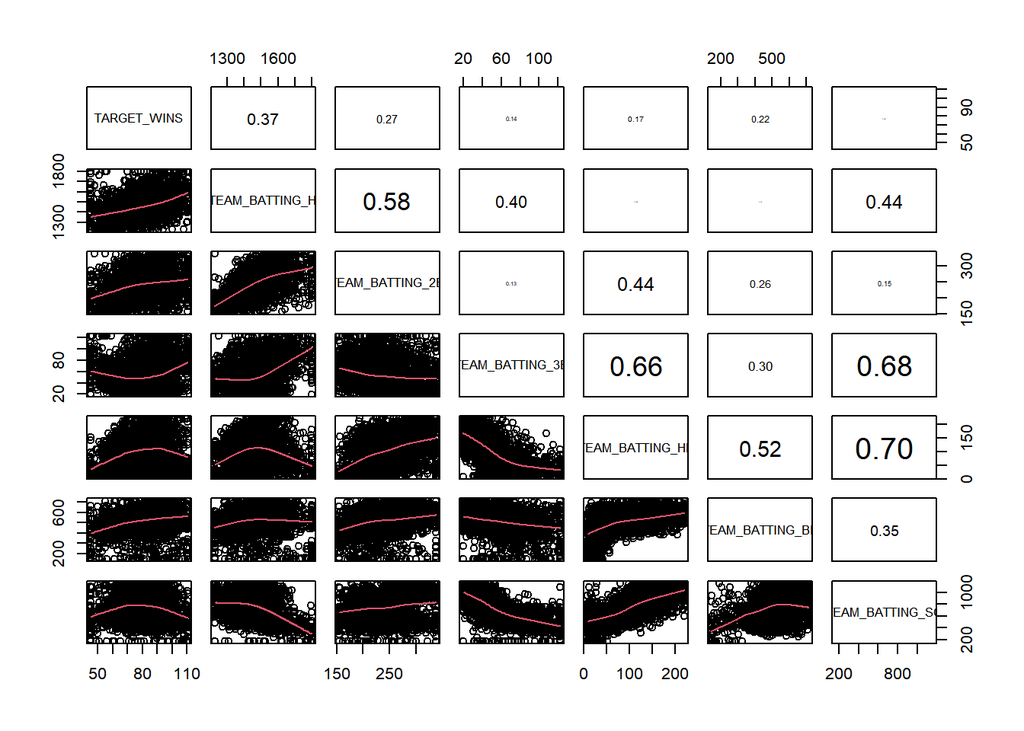

```r
# Scatterplot Matrix
panel.cor <- function(x, y, digits=2, prefix="", cex.cor, ...)
{
  usr <- par("usr"); on.exit(par(usr))
  par(usr = c(0, 1, 0, 1))
  r <- abs(cor(x, y))
  txt <- format(c(r, 0.123456789), digits=digits)[1]
  txt <- paste(prefix, txt, sep="")
  if(missing(cex.cor)) cex.cor <- 0.8/strwidth(txt)
  text(0.5, 0.5, txt, cex = cex.cor * r)
}

# Batting Stats and Wins
pairs(moneyball[1:7], lower.panel=panel.smooth, upper.panel = panel.cor)
```

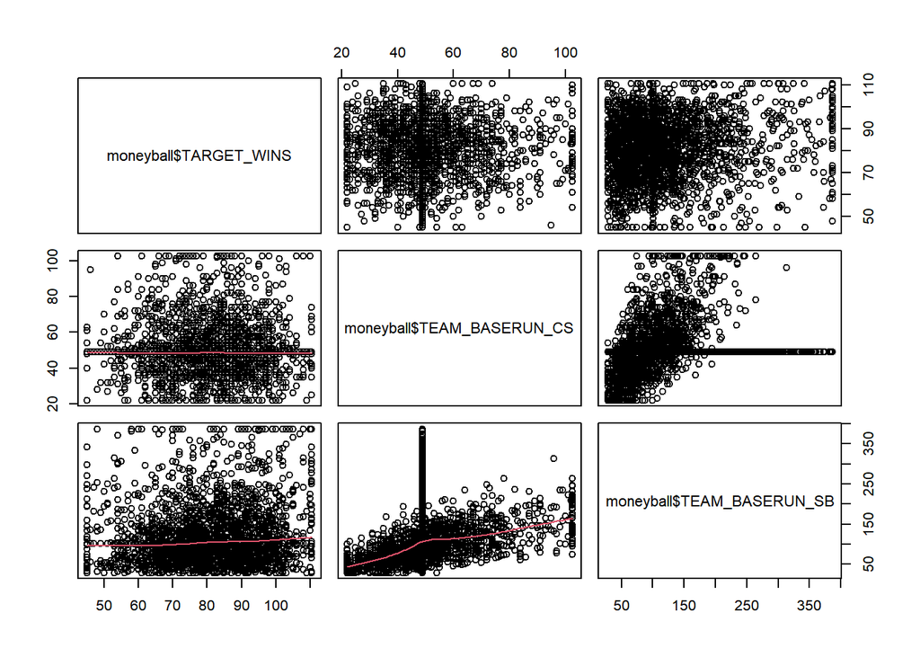

```r
#Baserunning  Stats and Wins
pairs(~ moneyball$TARGET_WINS + moneyball$TEAM_BASERUN_CS + moneyball$TEAM_BASERUN_SB, lower.panel = panel.smooth)
```

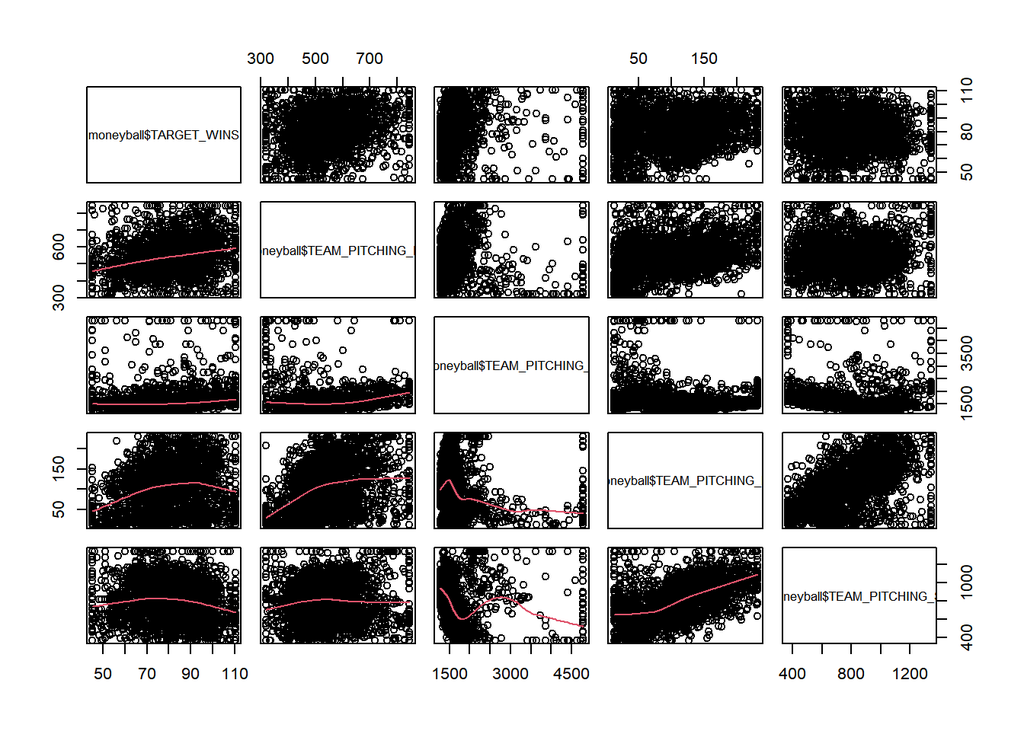

```r
#Pitcher Stats and Wins
pairs(~ moneyball$TARGET_WINS + moneyball$TEAM_PITCHING_BB + moneyball$TEAM_PITCHING_H +
        moneyball$TEAM_PITCHING_HR + moneyball$TEAM_PITCHING_SO, lower.panel = panel.smooth)
```

## Model Creation

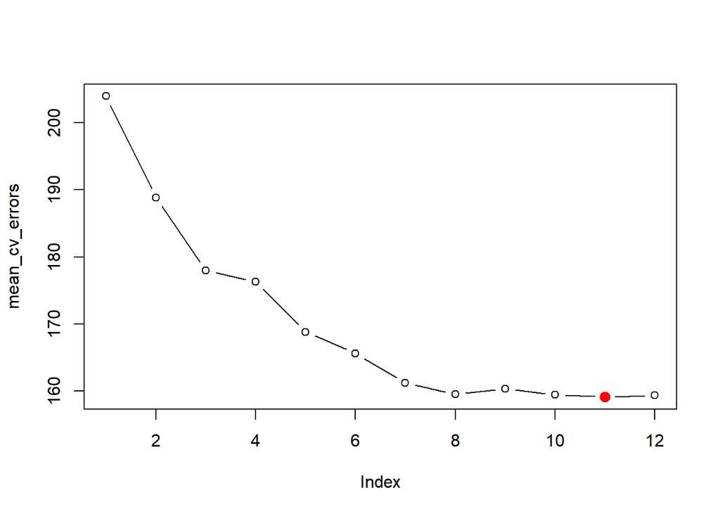

```r
#Function for Mean Square Error Calculation
mse <- function(sm)
  mean(sm$residuals^2)

#Set training and test sets
set.seed(1)
train <- sample(1:nrow(moneyball), as.integer(nrow(moneyball) * .7))
test <- (-train)

# All Subsets Regression

#create predict function for regsubsets
predict.regsubsets <- function(object, newdata, id,...) {
  form <- as.formula(object$call[[2]])
  mat <- model.matrix(form, newdata)
  coefi <- coef(object, id = id)
  xvars <- names(coefi)
  mat[,xvars]%*%coefi
}

#Generate 10 folds
k <- 10
set.seed(3)
folds <- sample(1:k, nrow(moneyball), replace = TRUE)

#Create matrix to store MSE
cv_errors <- matrix(NA, k, 12, dimnames = list(NULL, paste(1:12)))

#Iterate through each fold and calculate MSE
for(j in 1:k){

  best_fit = regsubsets(TARGET_WINS ~ TEAM_BATTING_1B + TEAM_BATTING_2B + TEAM_BATTING_3B + TEAM_BATTING_HR +
                          TEAM_BATTING_NH+ TEAM_BASERUN_SB + TEAM_BASERUN_CS +TEAM_BATTING_HBP + TEAM_PITCHING_H +
                          TEAM_PITCHING_SO + TEAM_FIELDING_E + TEAM_FIELDING_DP, data = moneyball[folds!=j,], nvmax=12)

  for(i in 1:12){
    pred = predict(best_fit, moneyball[folds==j,], id=i)
    cv_errors[j,i] = mean((moneyball$TARGET_WINS[folds==j]-pred)^2)
  }
}

#Plot minimum MSE
mean_cv_errors = apply(cv_errors, 2, mean)
min = which.min(mean_cv_errors)
plot(mean_cv_errors, type='b')
points(min, mean_cv_errors[min][1], col = "red", cex = 2, pch = 20)
```

```r
#Print minimum MSE
min
```

```
## 11
## 11
```

```r
reg_best <- regsubsets(TARGET_WINS ~ TEAM_BATTING_1B + TEAM_BATTING_2B + TEAM_BATTING_3B + TEAM_BATTING_HR +
                        TEAM_BATTING_NH+ TEAM_BASERUN_SB + TEAM_BASERUN_CS +TEAM_BATTING_HBP + TEAM_PITCHING_H +
                       TEAM_PITCHING_SO + TEAM_FIELDING_E + TEAM_FIELDING_DP, data = moneyball, nvmax = 12)
#Print Model Coefficients
coef(reg_best, 11)
```

```
##      (Intercept)  TEAM_BATTING_1B  TEAM_BATTING_2B  TEAM_BATTING_3B
##     32.584313776      0.030999961      0.018190909      0.150615449
##  TEAM_BATTING_HR  TEAM_BATTING_NH  TEAM_BASERUN_SB  TEAM_BASERUN_CS
##      0.112556510      0.014552924      0.035873864     -0.024239303
##  TEAM_PITCHING_H TEAM_PITCHING_SO  TEAM_FIELDING_E TEAM_FIELDING_DP
##      0.005231718      0.007506657     -0.031118112     -0.108064329
```

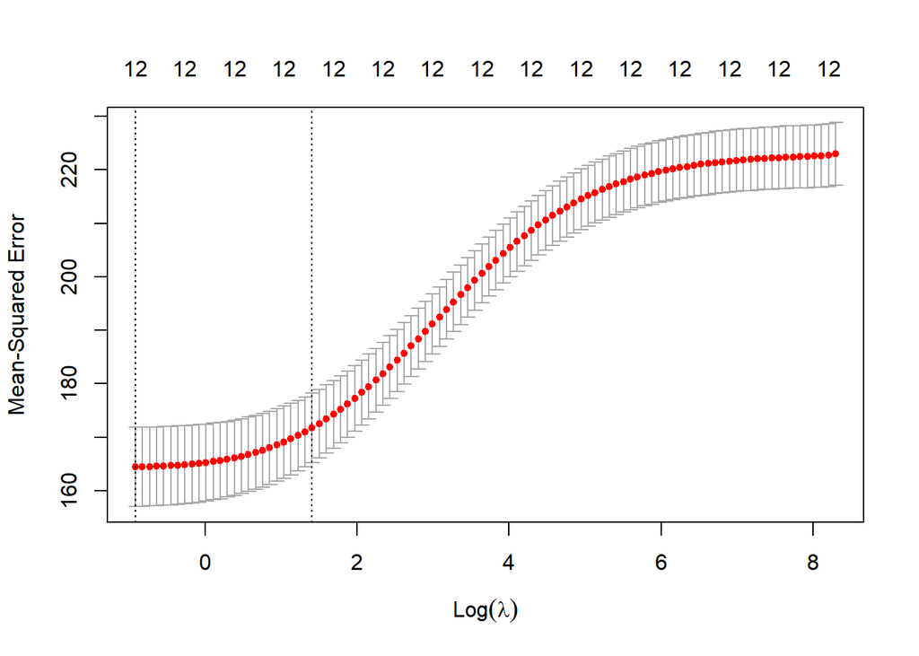

```r
#Ridge Regression

#Create x and y components
x <- model.matrix(TARGET_WINS ~ TEAM_BATTING_1B + TEAM_BATTING_2B + TEAM_BATTING_3B + TEAM_BATTING_HR +
                    TEAM_BATTING_NH+ TEAM_BASERUN_SB + TEAM_BASERUN_CS +TEAM_BATTING_HBP + TEAM_PITCHING_H +
                    TEAM_PITCHING_SO + TEAM_FIELDING_E + TEAM_FIELDING_DP, moneyball)[,-1]
y <- moneyball$TARGET_WINS

#Choose tuning variable value
set.seed(2)
cv.out <- cv.glmnet(x[train,], y[train], alpha = 0)
plot(cv.out)
```

```r
bestlam.ridge<- cv.out$lambda.min
bestlam.ridge
```

```
## [1] 0.4004828
```

```r
#Perform ridge regression on training and validation sets
ridge <- glmnet(x, y, alpha = 0)
ridge.pred.train <- predict(ridge, s = bestlam.ridge, newx = x[train,])
ridge.pred.test <- predict(ridge, s = bestlam.ridge, newx = x[test,])

#Print coefficients after performing ridge regression on entire data set
predict(ridge, type = "coefficients", s = bestlam.ridge)
```

```
## 13 x 1 sparse Matrix of class "dgCMatrix"
##                             1
## (Intercept)      32.914231231
## TEAM_BATTING_1B   0.030038891
## TEAM_BATTING_2B   0.025037718
## TEAM_BATTING_3B   0.134814510
## TEAM_BATTING_HR   0.105368861
## TEAM_BATTING_NH   0.013051293
## TEAM_BASERUN_SB   0.033625084
## TEAM_BASERUN_CS  -0.022578877
## TEAM_BATTING_HBP  0.026417799
## TEAM_PITCHING_H   0.004124266
## TEAM_PITCHING_SO  0.005958894
## TEAM_FIELDING_E  -0.026669625
## TEAM_FIELDING_DP -0.101440376
```

```r
#R Squared Funtionc
eval_results <- function(true, predicted, df) {
  SSE <- sum((predicted -true)^2)
  SST <- sum((true - mean(true))^2)
  R_square <- 1 - SSE/SST
  MSE <- SSE/nrow(df)
  out <- paste("R^2:", R_square, "MSE:", MSE,"\n",  sep = "\n")
  cat(out[1])
}

#Print R^2 and MSE for Ridge Regression
eval_results(y[train], ridge.pred.train, x[train,])
```

```
## R^2:
## 0.276212821129862
## MSE:
## 161.207873004056
```

```r
eval_results(y[test], ridge.pred.test, x[test,])
```

```
## R^2:
## 0.303754164845564
## MSE:
## 147.542532544531
```

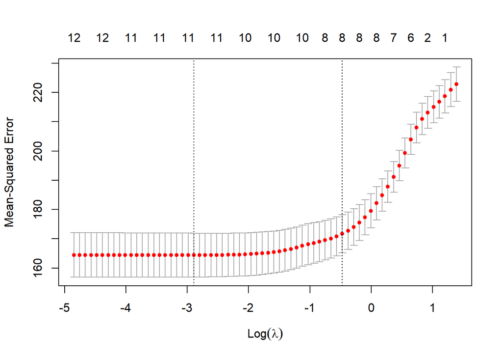

```r
#Lasso

#Choose tuning variable value
set.seed(2)
cv.out <- cv.glmnet(x[train,], y[train], alpha = 1)
plot(cv.out)
```

```r
bestlam.lasso<- cv.out$lambda.min
bestlam.lasso
```

```
## [1] 0.05546231
```

```r
#Perform lasso on training and validation sets
lasso <- glmnet(x, y, alpha = 1)
lasso.pred.train <- predict(lasso, s = bestlam.lasso, newx = x[train,])
lasso.pred.test <- predict(lasso, s = bestlam.lasso, newx = x[test,])

#Print coefficients after performing lasso on entire data set
predict(lasso, type = "coefficients", s = bestlam.lasso)
```

```
## 13 x 1 sparse Matrix of class "dgCMatrix"
##                             1
## (Intercept)      33.859160723
## TEAM_BATTING_1B   0.030299304
## TEAM_BATTING_2B   0.019781753
## TEAM_BATTING_3B   0.144461888
## TEAM_BATTING_HR   0.111598574
## TEAM_BATTING_NH   0.012782474
## TEAM_BASERUN_SB   0.034598101
## TEAM_BASERUN_CS  -0.018974815
## TEAM_BATTING_HBP  0.004779997
## TEAM_PITCHING_H   0.004731139
## TEAM_PITCHING_SO  0.005504918
## TEAM_FIELDING_E  -0.028706391
## TEAM_FIELDING_DP -0.104039848
```

```r
#Print R^2 and MSE for lasso
eval_results(y[train], lasso.pred.train, x[train,])
```

```
## R^2:
## 0.276368983522857
## MSE:
## 161.173091222956
```

```r
eval_results(y[test], lasso.pred.test, x[test,])
```

```
## R^2:
## 0.306935557378593
## MSE:
## 146.868358728845
```

## Model Selection

The data was analyzed using three different methods. The first method used was the Best Subset method. This method compares all possible subsets of data and outputs the mean squared error among other statistics. K Folds Cross Validation with ten folds was used to help reduce the variance in the mean squared error reported. After cross validating, the eleven variable model was chosen for the Best Subsets method. Based on the mean squared error being the highest of the three models, this model was not chosen as the final model.

The second method used was Ridge Regression. This method is very similar to the Least Squares approach for linear regression, however there is a shrinkage penalty term that minimizes some of the coefficients for variables. There is a tuning parameter $\lambda$ that controls the impact of this shrinkage term. The data was split into a training and test set. Ridge Regression was applied to the training set and the $\lambda$ value that lead to the lowest mean squared error was used. K Folds Cross Validation with ten folds was used to minimize the variance in the mean squared error. Ridge Regression was then applied to the test set using the previously determined $\lambda$ value.

The third method used was the Lasso. This method is similar to Ridge Regression, however there is an extra term in the equation that allows variable coefficients to equal zero. The data was split into a training and test set. The Lasso was used on the training set and the $\lambda$ value that lead to the lowest mean squared error was used. K Folds Cross Validation with ten folds was used to minimize the variance in the mean squared error. The Lasso was then applied to the test set using the previously determined $\lambda$ value. Based on having a lower mean squared error than the Ridge Regression model, the Lasso model was chosen as the final model.